# Chad - trigger development

Analysis last updated 2022-01-03

For Chad an OCHA anticipatory action framework is being developed to anticipate drought. Such a framework consists of activities, financing, and a trigger. This document summarizes the work done by the Centre for Humanitarian Data (CHD), whose work focuses on the development of the trigger. The development of the trigger in Chad has been a collaborative process for which a preliminary trigger was proposed by a technical working group consisting of several in-country organizations. The validation and fine-tuning of this trigger was thereafter executed by CHD.

## Context

- area of interest –> ignore trade
- rainy season - JJAS but JA main months
- github

## Preliminary trigger

The preliminary trigger was as follows:

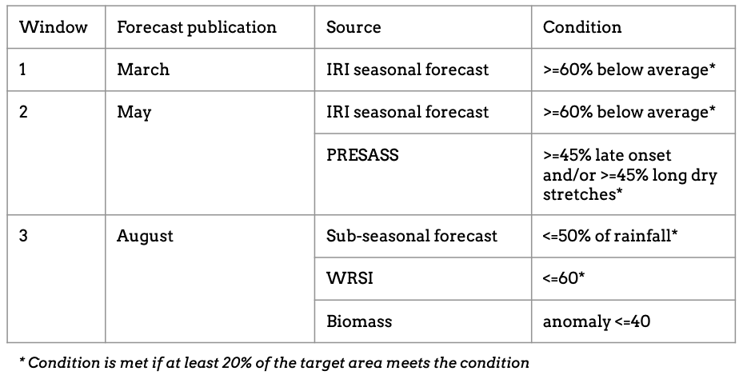

Proposed preliminary trigger

## Trigger validation

This validation consisted of four steps: 1) compiling a list of historical socio-economic years 2) extract the **observed** values of the trigger indicators at the end of the rainy season and see how these correlate with the list of historical drought years 3) extract the date of the same trigger indicators but that is **forecasted** or available during the rainy season and see how these correlate with the **observed** end of season data. 4) if no strong correlation in 2) or 3) test correlations with the same indicators but at different thresholds.

### Historical socio-economic drought

With anticipatory action we want to anticipate droughts that cause an increase in humanitarian needs. Such droughts are often referred to as socio-economic droughts. Therefore for a historical analysis of years we would have wanted to release anticipatory funds, a list of historical socio-economic droughts is needed. This kind of impact data is not widely available, both temporarily and spatially.

Nevertheless, we attempted to compile a list of worst drought years. This list is by no means fully validated and shouldn’t be seen as a ground-truth dataset. We therefore use the list for part of the analyses but don’t base all decisions on it. The list was compiled in discussion with CERF colleagues and based on several sources. [no spatial data] One source is the official drought declarations. These are known to be in 2005/2006, 2009/2010, 2016/2017 [though we don’t have the reference.. ]

Another source are the CERF allocations since 2006. These were in 2010-01, 2011-12, and 2018-05. Analyzing the documents these allocations were in response to poor rainy seasons during 2009, 2011, and 2017.

Then there is FewsNet which maps the food insecurity situation. In their reports the causes of food insecurity are often mentioned and thus we can use these reports to look for a mention of meteorological drought. We scanned this manually. [The 2010 report](https://fews.net/sites/default/files/documents/reports/Chad_ol_2010_01_en.pdf) indicates increased food insecurity caused by erratic patterns during the 2009 rainy season. In 2011 a shorter than usual rainy season is mentioned. 2017 mentions localized dry spells causing bad pastoral conditions.

Lastly, we can inspect other sources of literature such as the African Risk Capacity 2016/17 operations plan and the 2017 multi-risk contigency plan. [we have the documents but couldn’t find them online]

ARC reports 1968 to 1973, 1983, 1984, 2004, and 2009 as drought years.

The multi-risk contigency plan reports the years 1969, 1981, 1993, 1997, 2001, 2009, and 2012. For both sources it is unclear if these years refer to the rainy season or the lean season. Moreover, while they do contain detailed information they don’t clearly cite the source of the information.

All in all, we can see that the different sources slightly diverge. Moreover, with the reports of FewsNet and CERF we see that there are still different causes of meteorological drought, e.g. overall deficitis of rain, erratic pattterns both temporal and spatial, and dry spells.

We take the union of the different sources. With the exception of 2012 as we assume this refers to the drought observed in 2011. We thus get as drought years list: 1968-1973, 1983, 1984, 1993, 1997, 2001, 2004, 2005, 2009, 2011, and 2017. Note that three of the five sources only include data after 2004.

[We could further dive into the FN reports.. basically now we only checked the years for which there were CERF allocations] [what to do with the drought declarations? I am not convinced by the 2005 year.. might be caused by 2004? ] [Make a table with the different sources? ]

### Observed end-of-season indicators

#### Below average rainfall

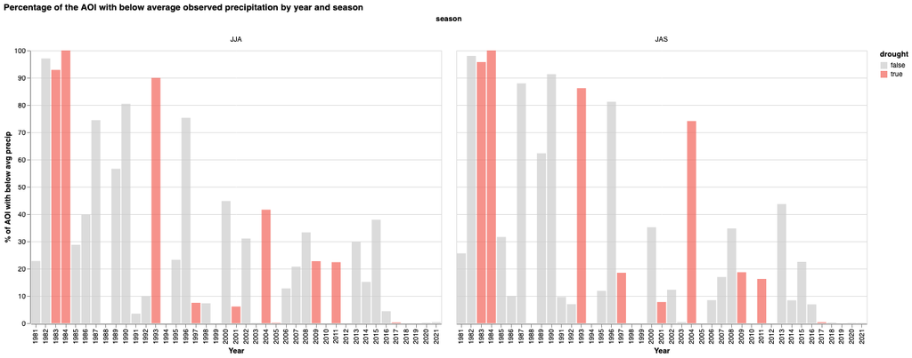

From these graphs, we can conclude several things: - In the 80s there was a particularly dry period. This is also confirmed by other sources. - Since 2000 the 5 years with the largest percentage of below average rainfall were 2000, 2004, 2008, 2013, and 2015. - Since 2017 we haven’t seen any significant percentage of below average rainfall. - There is a limited correlation between below average precipitation and the list of socio-economic droughts. It is important to note here that the list of historical droughts is not fully validated and thus not too many conclusions should be drawn to it. For example the 2005 drought might refer to the 2004 rainy season. Nevertheless, for example in 2017 we know there was localized meteorological drought that are clearly not reflected in the below average seasonal precipitation.

[Do you think we should show a confusion matrix here as well?]

[figure not shown]